# Assignment_3_rmd

Emily

10/10/2019

## Question 2 a

```r
Letters <- read_csv("Letters.csv")
Letters$isB = as.factor(Letters$letter == "B")

train.ids = sample(nrow(Letters), .65*nrow(Letters))
Letters.train = Letters[train.ids,]
Letters.test = Letters[-train.ids,]
```

### Question 2 ai

```r
Letters.train.mod <- Letters.train %>%
  dplyr::select(-letter)

Letters.test.mod <- Letters.test %>%
  dplyr::select(-letter)

table(Letters.train.mod$isB)
```

```
##
## FALSE  TRUE
##  1522   503
```

```r
accuracy_isb_baseline = length(Letters.train.mod$isB[Letters.train.mod$isB== FALSE])/nrow(Letters.train.mod)
accuracy_isb_baseline
```

```
## [1] 0.7516049
```

```r
table(Letters.test.mod$isB)
```

```
##
## FALSE  TRUE
##   828   263
```

```r
accuracy_isb_baseline_t = length(Letters.test.mod$isB[Letters.test.mod$isB== FALSE])/nrow(Letters.test.mod)
accuracy_isb_baseline_t
```

```
## [1] 0.7589368
```

The accuracy of the baseline model (a model assuming that none of the letters are B) is 0.7516049 on the training set.

The accuracy of the baseline model is 0.7589368 on the test set.

### Question 2 aii

```r
mod1 <- glm(isB ~., data=Letters.train.mod, family="binomial")
summary(mod1)
```

```
##
## Call:
## glm(formula = isB ~ ., family = "binomial", data = Letters.train.mod)
##
## Deviance Residuals:
##     Min       1Q   Median       3Q      Max
## -3.2216  -0.1300  -0.0137   0.0000   3.1817
##
## Coefficients:
##              Estimate Std. Error z value Pr(>|z|)
## (Intercept) -16.11881    2.61100  -6.173 6.68e-10 ***
## xbox         -0.09327    0.12436  -0.750  0.45324
## ybox          0.11577    0.09070   1.276  0.20180
## width        -1.19050    0.16117  -7.386 1.51e-13 ***
## height       -0.86584    0.14712  -5.885 3.98e-09 ***
## onpix         0.95595    0.13438   7.114 1.13e-12 ***
## xbar          0.68594    0.13448   5.100 3.39e-07 ***
## ybar         -0.51675    0.12400  -4.167 3.08e-05 ***
## x2bar        -0.42539    0.10107  -4.209 2.57e-05 ***
## y2bar         1.40838    0.13218  10.655  < 2e-16 ***
## xybar         0.24066    0.09245   2.603  0.00924 **
## x2ybar        0.62938    0.12710   4.952 7.34e-07 ***
## xy2bar       -0.51870    0.11073  -4.685 2.81e-06 ***
## xedge        -0.19994    0.09565  -2.090  0.03660 *
## xedgeycor     0.07124    0.10846   0.657  0.51129
## yedge         1.81887    0.13719  13.258  < 2e-16 ***
## yedgexcor     0.37484    0.07279   5.150 2.61e-07 ***
## ---
## Signif. codes:  0 '***' 0.001 '**' 0.01 '*' 0.05 '.' 0.1 ' ' 1
##
## (Dispersion parameter for binomial family taken to be 1)
##
##     Null deviance: 2270.29  on 2024  degrees of freedom
## Residual deviance:  612.68  on 2008  degrees of freedom
## AIC: 646.68
##
## Number of Fisher Scoring iterations: 8
```

```r
let.test_b = predict(mod1, newdata=Letters.test.mod, type="response")

summary(let.test_b)
```

```
##      Min.   1st Qu.    Median      Mean   3rd Qu.      Max.
## 0.0000000 0.0000834 0.0115908 0.2471750 0.4306878 0.9998870
```

```r
t1 = table(Letters.test.mod$isB, let.test_b > 0.5)
t1
```

```
##
##         FALSE TRUE
##   FALSE   796   32
##   TRUE     30  233
```

```r
table(Letters.test.mod$isB)
```

```
##
## FALSE  TRUE
##   828   263
```

```r
accuracy_isb = (t1[1,1]+t1[2,2])/nrow(Letters.test.mod)
accuracy_isb
```

```
## [1] 0.9431714
```

The accuracy of the logistic model for predicting B on the test set is 0.9431714.

### Question 2 a iii

AUC of logistic regression model

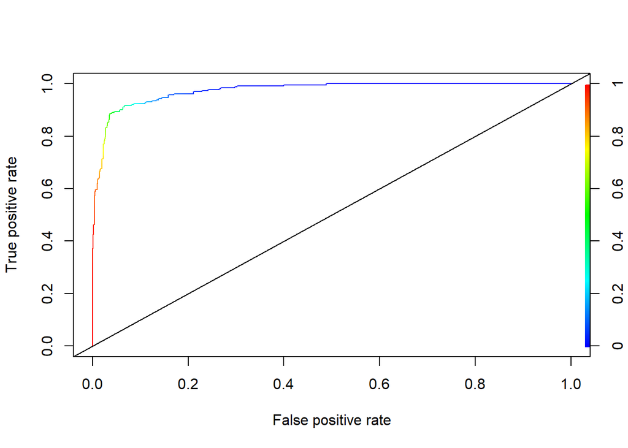

```r
rocr.log.pred <- prediction(let.test_b, Letters.test.mod$isB)
logPerformance <- performance(rocr.log.pred, "tpr", "fpr")
plot(logPerformance, colorize = TRUE)
abline(0, 1)
```

```r
auc = as.numeric(performance(rocr.log.pred, "auc")@y.values)
```

The Auc is 0.9741096.

### Question 2 a iv

CART modeling B

```r
modCART <- rpart(isB ~.,
            data = Letters.train.mod, method="class",
            minbucket=5, cp = 0.001)
modCART
```

```
## n= 2025
##
## node), split, n, loss, yval, (yprob)
##       * denotes terminal node
##
##   1) root 2025 503 FALSE (0.75160494 0.24839506)
##     2) yedge< 5.5 1356 122 FALSE (0.91002950 0.08997050)
##       4) y2bar< 4.5 921  15 FALSE (0.98371336 0.01628664)
##         8) width>=1.5 906  11 FALSE (0.98785872 0.01214128) *
##         9) width< 1.5 15   4 FALSE (0.73333333 0.26666667)
##          18) ybar>=8.5 10   0 FALSE (1.00000000 0.00000000) *
##          19) ybar< 8.5 5   1 TRUE (0.20000000 0.80000000) *
##       5) y2bar>=4.5 435 107 FALSE (0.75402299 0.24597701)
##        10) ybar>=7.5 228  18 FALSE (0.92105263 0.07894737)
##          20) yedge< 4.5 157   2 FALSE (0.98726115 0.01273885) *
##          21) yedge>=4.5 71  16 FALSE (0.77464789 0.22535211)
##            42) height>=3.5 61   8 FALSE (0.86885246 0.13114754)
##              84) xbar< 7.5 37   1 FALSE (0.97297297 0.02702703) *
##              85) xbar>=7.5 24   7 FALSE (0.70833333 0.29166667)
##               170) xedgeycor< 7.5 17   2 FALSE (0.88235294 0.11764706) *
##               171) xedgeycor>=7.5 7   2 TRUE (0.28571429 0.71428571) *
##            43) height< 3.5 10   2 TRUE (0.20000000 0.80000000) *
##        11) ybar< 7.5 207  89 FALSE (0.57004831 0.42995169)
##          22) xedgeycor< 7.5 105  10 FALSE (0.90476190 0.09523810)
##            44) yedge< 4.5 83   2 FALSE (0.97590361 0.02409639) *
##            45) yedge>=4.5 22   8 FALSE (0.63636364 0.36363636)
##              90) x2bar>=3.5 13   2 FALSE (0.84615385 0.15384615) *
##              91) x2bar< 3.5 9   3 TRUE (0.33333333 0.66666667) *
##          23) xedgeycor>=7.5 102  23 TRUE (0.22549020 0.77450980)
##            46) xedgeycor>=8.5 20   5 FALSE (0.75000000 0.25000000)
##              92) width>=5.5 13   1 FALSE (0.92307692 0.07692308) *
##              93) width< 5.5 7   3 TRUE (0.42857143 0.57142857) *
##            47) xedgeycor< 8.5 82   8 TRUE (0.09756098 0.90243902)
##              94) xedge>=2.5 20   8 TRUE (0.40000000 0.60000000)
##               188) yedgexcor< 8.5 6   1 FALSE (0.83333333 0.16666667) *
##               189) yedgexcor>=8.5 14   3 TRUE (0.21428571 0.78571429) *
##              95) xedge< 2.5 62   0 TRUE (0.00000000 1.00000000) *
##     3) yedge>=5.5 669 288 TRUE (0.43049327 0.56950673)
##       6) xy2bar>=7.5 260  63 FALSE (0.75769231 0.24230769)
##        12) yedge< 7.5 205  32 FALSE (0.84390244 0.15609756)
```

[output cut: 17 more lines]

```
##       7) xy2bar< 7.5 409  91 TRUE (0.22249389 0.77750611)
##        14) y2bar< 4.5 98  34 FALSE (0.65306122 0.34693878)
##          28) xybar>=7.5 44   3 FALSE (0.93181818 0.06818182) *
##          29) xybar< 7.5 54  23 TRUE (0.42592593 0.57407407)
##            58) y2bar< 2.5 10   0 FALSE (1.00000000 0.00000000) *
##            59) y2bar>=2.5 44  13 TRUE (0.29545455 0.70454545)
##             118) x2bar< 3.5 5   0 FALSE (1.00000000 0.00000000) *
##             119) x2bar>=3.5 39   8 TRUE (0.20512821 0.79487179) *
##        15) y2bar>=4.5 311  27 TRUE (0.08681672 0.91318328)
##          30) xybar>=12 7   0 FALSE (1.00000000 0.00000000) *
##          31) xybar< 12 304  20 TRUE (0.06578947 0.93421053)
##            62) x2ybar< 2.5 5   0 FALSE (1.00000000 0.00000000) *
##            63) x2ybar>=2.5 299  15 TRUE (0.05016722 0.94983278)
##             126) yedgexcor>=11.5 7   3 FALSE (0.57142857 0.42857143) *
##             127) yedgexcor< 11.5 292  11 TRUE (0.03767123 0.96232877) *
```

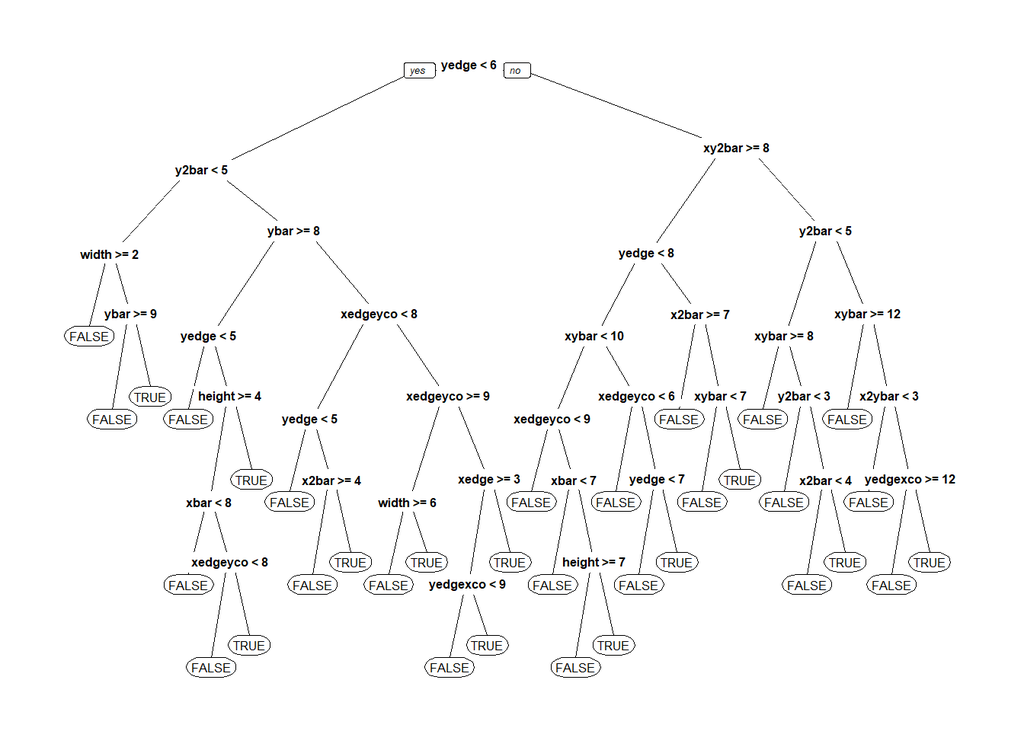

```r
prp(modCART)
```

```r
cpVals = data.frame(cp = seq(0, .04, by=.001))

set.seed(123)
train.cart <- train(isB ~.,
                    data = Letters.train.mod,
                    method = "rpart",
                    tuneGrid = cpVals,
                    trControl = trainControl(method = "cv", number=5),
                    metric = "Accuracy")

# look at the cross validation results, stored as a data-frame
# https://machinelearningmastery.com/machine-learning-evaluation-metrics-in-r/
train.cart$results # please ignore kappa
```

```
##       cp  Accuracy     Kappa  AccuracySD    KappaSD
## 1  0.000 0.9209899 0.7861343 0.005188157 0.01330092
## 2  0.001 0.9195121 0.7812804 0.008026582 0.02294331
## 3  0.002 0.9195121 0.7812804 0.008026582 0.02294331
## 4  0.003 0.9190195 0.7810613 0.009048200 0.02442099
## 5  0.004 0.9185244 0.7798413 0.008994524 0.02448740
## 6  0.005 0.9125924 0.7651210 0.010122099 0.02329267
## 7  0.006 0.9125924 0.7638961 0.010122099 0.02293542
## 8  0.007 0.9155553 0.7704631 0.013457533 0.03301462
## 9  0.008 0.9160552 0.7707294 0.014655179 0.03932101
## 10 0.009 0.9125985 0.7579005 0.015913317 0.04696195
## 11 0.010 0.9125985 0.7574186 0.015026604 0.04515616
## 12 0.011 0.9125985 0.7574186 0.015026604 0.04515616
## 13 0.012 0.9125985 0.7562341 0.015026604 0.04657954
## 14 0.013 0.9101293 0.7473883 0.012600478 0.03684722
```

[output cut: 27 more lines]

```r
train.cart
```

```
## CART
##
## 2025 samples
##   16 predictor
##    2 classes: 'FALSE', 'TRUE'
##
## No pre-processing
## Resampling: Cross-Validated (5 fold)
## Summary of sample sizes: 1620, 1620, 1620, 1619, 1621
## Resampling results across tuning parameters:
##
##   cp     Accuracy   Kappa
##   0.000  0.9209899  0.7861343
##   0.001  0.9195121  0.7812804
##   0.002  0.9195121  0.7812804
##   0.003  0.9190195  0.7810613
##   0.004  0.9185244  0.7798413
##   0.005  0.9125924  0.7651210
##   0.006  0.9125924  0.7638961
##   0.007  0.9155553  0.7704631
##   0.008  0.9160552  0.7707294
##   0.009  0.9125985  0.7579005
##   0.010  0.9125985  0.7574186
##   0.011  0.9125985  0.7574186
##   0.012  0.9125985  0.7562341
##   0.013  0.9101293  0.7473883
##   0.014  0.9101293  0.7473883
##   0.015  0.9061848  0.7346725
##   0.016  0.9061848  0.7346725
##   0.017  0.9027365  0.7205766
##   0.018  0.9002637  0.7150562
##   0.019  0.9002637  0.7150562
##   0.020  0.8943378  0.6965067
##   0.021  0.8943378  0.6965067
##   0.022  0.8943378  0.6965067
##   0.023  0.8943378  0.6965067
##   0.024  0.8943378  0.6965067
##   0.025  0.8913773  0.6882623
##   0.026  0.8913773  0.6882623
##   0.027  0.8864390  0.6714428
##   0.028  0.8869328  0.6734223
##   0.029  0.8869328  0.6734223
##   0.030  0.8869328  0.6734223
##   0.031  0.8869328  0.6734223
##   0.032  0.8869328  0.6734223
##   0.033  0.8869328  0.6734223
##   0.034  0.8869328  0.6734223
##   0.035  0.8839637  0.6631562
##   0.036  0.8839637  0.6631562
##   0.037  0.8839637  0.6631562
##   0.038  0.8790242  0.6479163
##   0.039  0.8745688  0.6305697
##   0.040  0.8745688  0.6305697
##
## Accuracy was used to select the optimal model using the largest value.
## The final value used for the model was cp = 0.
```

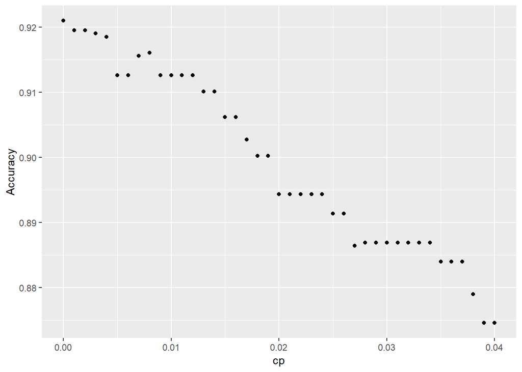

```r
# plot the results
ggplot(train.cart$results, aes(x=cp, y=Accuracy)) + geom_point()
```

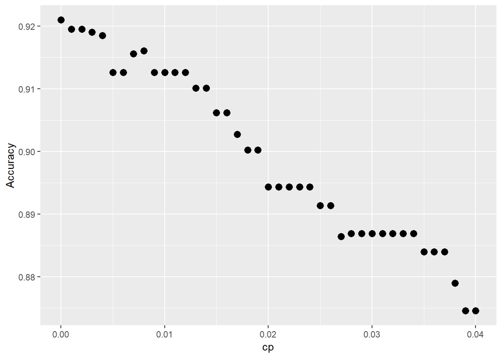

```r
# We can increase the size of the points:
ggplot(train.cart$results, aes(x=cp, y=Accuracy)) + geom_point(size=3)
```

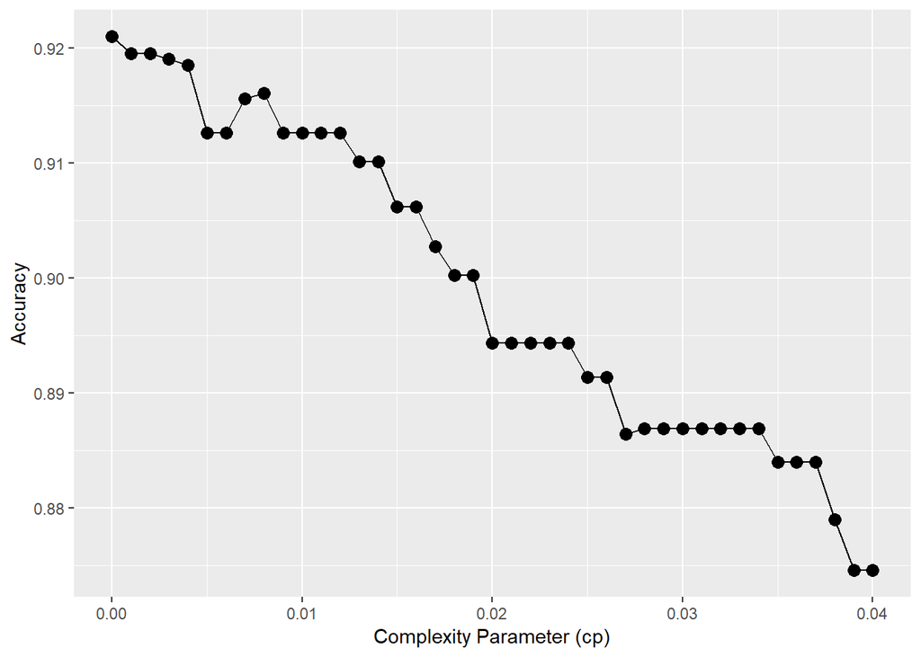

```r
# We can change the default axis labels
ggplot(train.cart$results, aes(x=cp, y=Accuracy)) + geom_point(size=3) +
  xlab("Complexity Parameter (cp)") + geom_line()
```

```r
# Extract the best model and make predictions
train.cart$bestTune
```

```
##   cp
## 1  0
```

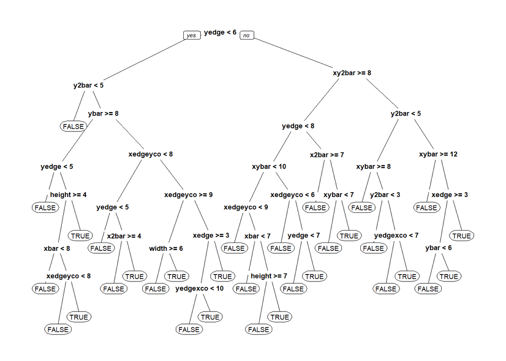

```r
mod123 = train.cart$finalModel
prp(mod123, digits=3)
```

```r
Letters.test.mm = as.data.frame(model.matrix(isB~.+0, data=Letters.test.mod))
pred_cart = predict(mod123, newdata=Letters.test.mm, type="class")
tcart = table(Letters.test.mod$isB, pred_cart)

accuracy_isb_cart = (tcart[1,1]+tcart[2,2])/nrow(Letters.test.mod)
accuracy_isb_cart
```

```
## [1] 0.9303391
```

The accuracy of the CART model is 0.9303391. The cp value chosed to construct the CART model is 0. This value is chosen by cross validation; the model is run repeatedly with a set seed and one trial for each cp value from 0 to .04 increaing by .001 intervals, and the cp value which produces the highest training set accuracy is selected.